# Coursework

Enriq Mah Xing Yao

Loading in the libraries

## Question 2

**Reading the files and establishing data frames**

```r
airports_df <- read.csv("airports.csv", header = TRUE)
carriers_df <- read.csv("carriers.csv", header = TRUE)
planes_df <- read.csv("plane-data.csv", header = TRUE)

manifest_df <- data.frame()
for (year in 1990:1999) {
  file_name <- paste0(year, ".csv")
  current_data <- read.csv(file_name)
  current_data <- distinct(current_data)
  current_data <- current_data %>%
    dplyr :: select(-AirTime,-CancellationCode,-CarrierDelay,-WeatherDelay,-NASDelay,-LateAircraftDelay,-SecurityDelay,-FlightNum,-Origin,-Dest,-TaxiIn,-TaxiOut,-Cancelled) %>%  #Dropping unused columns
    filter(ActualElapsedTime >= 0|is.na(ActualElapsedTime), CRSElapsedTime >= 0| is.na(CRSElapsedTime),DepTime <  2400|is.na(DepTime),ArrTime <  2400|is.na(ArrTime)) #filters for times = 0 or na
  # dplyr :: select is used to specify that the select function is from dplyr and not from MASS
  manifest_df <- rbind(manifest_df, current_data)
}
```

## Overview of the descriptive statistcis

Looking at the overall summary of the data, “ActualElapsedTime”, “CRSElapsedTime” and “AirTime” should not be able to take negative numbers indicating that there is an error in the data. As such the rows with a negative value for “ActualElapsedTime”and “CRSElapsedTime” will be removed from the main data frame “manifest_df”.

“AirTime”, “FlightNum”, “Origin”, “Dest”, “TaxiIn”, “TaxiOut” will not be used in the analysis and this it is removed.

Since the entire analysis is going to be looking solely at delays, where cancelled flights would not be considered delays, “cancelled” is also removed.

“cancellationcode”, “carrierdelay”, “Weatherdelay”, “SecurityDelay”, “NASdelay” and “lateaircraftdelay” are only populated from 2003 to 2006, as such we do not have all 10 years to analyse and thus these rows will also be ommited.

The data is cleaned at an earlier stage to reduce memory load.

## Descriptive Statistics

```r
# Shows the type of data each column
str(manifest_df)
```

```
## 'data.frame':    52673426 obs. of  16 variables:
##  $ Year             : int  1990 1990 1990 1990 1990 1990 1990 1990 1990 1990 ...
##  $ Month            : int  1 1 1 1 1 1 1 1 1 1 ...
##  $ DayofMonth       : int  3 4 5 6 8 9 10 11 12 13 ...
##  $ DayOfWeek        : int  3 4 5 6 1 2 3 4 5 6 ...
##  $ DepTime          : int  1707 1706 1629 1633 1630 1734 1634 1745 1650 1629 ...
##  $ CRSDepTime       : int  1630 1630 1630 1630 1630 1630 1630 1630 1630 1630 ...
##  $ ArrTime          : int  1755 1807 1715 1718 1726 1818 1723 1833 1742 1716 ...
##  $ CRSArrTime       : int  1723 1723 1723 1723 1723 1723 1723 1723 1723 1723 ...
##  $ UniqueCarrier    : chr  "US" "US" "US" "US" ...
##  $ TailNum          : chr  NA NA NA NA ...
##  $ ActualElapsedTime: int  48 61 46 45 56 44 49 48 52 47 ...
##  $ CRSElapsedTime   : int  53 53 53 53 53 53 53 53 53 53 ...
##  $ ArrDelay         : int  32 44 -8 -5 3 55 0 70 19 -7 ...
##  $ DepDelay         : int  37 36 -1 3 0 64 4 75 20 -1 ...
##  $ Distance         : int  182 182 182 182 182 182 182 182 182 182 ...
##  $ Diverted         : int  0 0 0 0 0 0 0 0 0 0 ...
```

```r
#Descriptive statistics of manifest_df
summary(manifest_df)
```

```
##       Year          Month          DayofMonth      DayOfWeek
##  Min.   :1990   Min.   : 1.000   Min.   : 1.00   Min.   :1.00
##  1st Qu.:1992   1st Qu.: 4.000   1st Qu.: 8.00   1st Qu.:2.00
##  Median :1995   Median : 7.000   Median :16.00   Median :4.00
##  Mean   :1995   Mean   : 6.528   Mean   :15.72   Mean   :3.94
##  3rd Qu.:1997   3rd Qu.:10.000   3rd Qu.:23.00   3rd Qu.:6.00
##  Max.   :1999   Max.   :12.000   Max.   :31.00   Max.   :7.00
##
##     DepTime         CRSDepTime      ArrTime          CRSArrTime
##  Min.   :   1     Min.   :   0   Min.   :   1      Min.   :   0
##  1st Qu.: 934     1st Qu.: 923   1st Qu.:1118      1st Qu.:1110
##  Median :1335     Median :1325   Median :1524      Median :1518
##  Mean   :1351     Mean   :1327   Mean   :1496      Mean   :1480
##  3rd Qu.:1739     3rd Qu.:1728   3rd Qu.:1918      3rd Qu.:1913
##  Max.   :2359     Max.   :2400   Max.   :2359      Max.   :2400
##  NA's   :892401                  NA's   :1018136
##  UniqueCarrier        TailNum          ActualElapsedTime CRSElapsedTime
##  Length:52673426    Length:52673426    Min.   :   0.0    Min.   :   0.0
##  Class :character   Class :character   1st Qu.:  68.0    1st Qu.:  70.0
##  Mode  :character   Mode  :character   Median :  99.0    Median : 100.0
##                                        Mean   : 117.2    Mean   : 117.8
##                                        3rd Qu.: 149.0    3rd Qu.: 149.0
##                                        Max.   :1883.0    Max.   :1613.0
##                                        NA's   :1018136   NA's   :24122
##     ArrDelay          DepDelay          Distance         Diverted
##  Min.   :-1437.0   Min.   :-1084.0   Min.   :  11.0   Min.   :0.000000
##  1st Qu.:   -6.0   1st Qu.:   -1.0   1st Qu.: 307.0   1st Qu.:0.000000
##  Median :    1.0   Median :    0.0   Median : 533.0   Median :0.000000
##  Mean   :    6.8   Mean   :    7.6   Mean   : 690.9   Mean   :0.002387
##  3rd Qu.:   11.0   3rd Qu.:    6.0   3rd Qu.: 929.0   3rd Qu.:0.000000
##  Max.   : 1808.0   Max.   : 1800.0   Max.   :4962.0   Max.   :1.000000
##  NA's   :1018136   NA's   :892401    NA's   :162818
```

## Classification and creation of new groupings

### What constitutes to a delay?

According to the United States Federal Aviation Administration (FAA), an aircraft is considered delayed when it is 15 minutes late than its scheduled time. Cancelled flights would classify as an anomaly and thus the data points with cancelled flights will be omitted in this particular analysis. The scheduled departure time is used as it is what travelers will be looking at when booking flights, thus, if we want to analyse delays and such we analyse form a traveler point of view

**Degrees of Delay**  
With the above in consideration, a flight would be considered on time when it is 15 minutes from its scheduled time. A passenger would be entitled for compensations if the flight is delayed by more than 3 hours. The mild classification would be considered if the delay is under 1 hour and the delay would be considered moderate if the delay is under 3 hours. As such the relevant groupings of the degree of delay are as follows (in minutes)  
* Ontime <= 15  
* Mild < 60  
* Moderate < 180  
* Major > 180

**Time of Day:**  
* Midnight(0000-0559)  
* Morning (0600-1159)  
* Afternoon(1200-1759)  
* Evening (1800-2359)

```r
#Defining a function to group time into time of day
group_time <- function(time){
  hour <- time %/% 100 #only takes in the first 2 digits of the time in HHMM
  if (hour < 6) {
    return("Midnight")
  } else if (hour < 12){
    return("Morning")
  } else if (hour < 18){
    return("Afternoon")
    } else{
    return("Evening")
  }
}
# Creates a new column called DepTimeOfDay and applying above function
manifest_df$DepTimeOfDay <- sapply(manifest_df$CRSDepTime,group_time)

group_delay <- function(time)
  if (is.na(time)){
    return(NULL)
  }  else if (time <= 15){
    return ("Ontime")
  } else if (time < 60){
    return("Mild")
  } else if (time < 180){
    return("Moderate")
  } else{
    return("Major")
  }
#Creates a new column called Degree_Of_Delay and applying above function
manifest_df$DegreeofDelay <- sapply(manifest_df$ArrDelay,group_delay)

# Convert Days and Months to strings
days_order <- c("Monday", "Tuesday", "Wednesday", "Thursday", "Friday", "Saturday", "Sunday")
months_order <- c("January", "February", "March", "April", "May", "June", "July", "August", "September", "October", "November", "December")

manifest_df <- manifest_df %>%
  mutate(DayOfWeekString = days_order[DayOfWeek],
         MonthString = months_order[Month])

#Finalised main data frame
print(head(manifest_df))
```

```
##   Year Month DayofMonth DayOfWeek DepTime CRSDepTime ArrTime CRSArrTime
## 1 1990     1          3         3    1707       1630    1755       1723
## 2 1990     1          4         4    1706       1630    1807       1723
## 3 1990     1          5         5    1629       1630    1715       1723
## 4 1990     1          6         6    1633       1630    1718       1723
## 5 1990     1          8         1    1630       1630    1726       1723
## 6 1990     1          9         2    1734       1630    1818       1723
##   UniqueCarrier TailNum ActualElapsedTime CRSElapsedTime ArrDelay DepDelay
## 1            US    <NA>                48             53       32       37
## 2            US    <NA>                61             53       44       36
## 3            US    <NA>                46             53       -8       -1
## 4            US    <NA>                45             53       -5        3
## 5            US    <NA>                56             53        3        0
## 6            US    <NA>                44             53       55       64
##   Distance Diverted DepTimeOfDay DegreeofDelay DayOfWeekString MonthString
## 1      182        0    Afternoon          Mild       Wednesday     January
## 2      182        0    Afternoon          Mild        Thursday     January
## 3      182        0    Afternoon        Ontime          Friday     January
## 4      182        0    Afternoon        Ontime        Saturday     January
## 5      182        0    Afternoon        Ontime          Monday     January
## 6      182        0    Afternoon          Mild         Tuesday     January
```

```r
#since the column degreeofdelay is not a string it is converted as such for future data visualization
manifest_df <- manifest_df %>%
  mutate(DegreeofDelay = map_chr(DegreeofDelay, toString))
str(manifest_df)
```

```
## 'data.frame':    52673426 obs. of  20 variables:
##  $ Year             : int  1990 1990 1990 1990 1990 1990 1990 1990 1990 1990 ...
##  $ Month            : int  1 1 1 1 1 1 1 1 1 1 ...
##  $ DayofMonth       : int  3 4 5 6 8 9 10 11 12 13 ...
##  $ DayOfWeek        : int  3 4 5 6 1 2 3 4 5 6 ...
##  $ DepTime          : int  1707 1706 1629 1633 1630 1734 1634 1745 1650 1629 ...
##  $ CRSDepTime       : int  1630 1630 1630 1630 1630 1630 1630 1630 1630 1630 ...
##  $ ArrTime          : int  1755 1807 1715 1718 1726 1818 1723 1833 1742 1716 ...
##  $ CRSArrTime       : int  1723 1723 1723 1723 1723 1723 1723 1723 1723 1723 ...
##  $ UniqueCarrier    : chr  "US" "US" "US" "US" ...
##  $ TailNum          : chr  NA NA NA NA ...
##  $ ActualElapsedTime: int  48 61 46 45 56 44 49 48 52 47 ...
##  $ CRSElapsedTime   : int  53 53 53 53 53 53 53 53 53 53 ...
##  $ ArrDelay         : int  32 44 -8 -5 3 55 0 70 19 -7 ...
##  $ DepDelay         : int  37 36 -1 3 0 64 4 75 20 -1 ...
##  $ Distance         : int  182 182 182 182 182 182 182 182 182 182 ...
##  $ Diverted         : int  0 0 0 0 0 0 0 0 0 0 ...
##  $ DepTimeOfDay     : chr  "Afternoon" "Afternoon" "Afternoon" "Afternoon" ...
##  $ DegreeofDelay    : chr  "Mild" "Mild" "Ontime" "Ontime" ...
##  $ DayOfWeekString  : chr  "Wednesday" "Thursday" "Friday" "Saturday" ...
##  $ MonthString      : chr  "January" "January" "January" "January" ...
```

```r
#Column names for report
colnames(manifest_df)
```

```
##  [1] "Year"              "Month"             "DayofMonth"
##  [4] "DayOfWeek"         "DepTime"           "CRSDepTime"
##  [7] "ArrTime"           "CRSArrTime"        "UniqueCarrier"
## [10] "TailNum"           "ActualElapsedTime" "CRSElapsedTime"
## [13] "ArrDelay"          "DepDelay"          "Distance"
## [16] "Diverted"          "DepTimeOfDay"      "DegreeofDelay"
## [19] "DayOfWeekString"   "MonthString"
```

## Part 2(a.i): When is the best time of day to fly to minimise delay?

For this portion we will consider the overall best time and best time for each year from 1990 to 1999

**Creating Data Frames to answer the question**

```r
#data frame for overall best time
time_of_day_df <- manifest_df %>%
  filter(!is.na(DepTimeOfDay), !is.na(DegreeofDelay) & DegreeofDelay != "") %>% #filters out the empty and 'na' rows
  count(DepTimeOfDay, DegreeofDelay) %>% #calculating the number of occurrences for each degree of delay
  group_by(DepTimeOfDay) %>%
  mutate(WeightedPercentage = round((n / sum(n)) * 100, 2)) #weighted percentage in 2dp

head(time_of_day_df,5)
```

```
## # A tibble: 5 × 4
## # Groups:   DepTimeOfDay [2]
##   DepTimeOfDay DegreeofDelay        n WeightedPercentage
##   <chr>        <chr>            <int>              <dbl>
## 1 Afternoon    Major            73997               0.38
## 2 Afternoon    Mild           3076425              15.7
## 3 Afternoon    Moderate        739309               3.78
## 4 Afternoon    Ontime        15652367              80.1
## 5 Evening      Major            56069               0.5
```

The average delay is calculated for each year by the time of day and plotted for each year

```r
#data frame for each year
tod_year_df <- manifest_df %>%
  group_by(Year, DepTimeOfDay) %>%
  summarise(AverageArrDelay = mean(ArrDelay, na.rm = TRUE), .groups = "drop") #.groups = "drop" removes the ArrDelay column used to calculate mean

head(tod_year_df,5)
```

```
## # A tibble: 5 × 3
##    Year DepTimeOfDay AverageArrDelay
##   <int> <chr>                  <dbl>
## 1  1990 Afternoon               7.52
## 2  1990 Evening                 9.75
## 3  1990 Midnight                3.26
## 4  1990 Morning                 4.38
## 5  1991 Afternoon               5.54
```

**Graph for visualization**

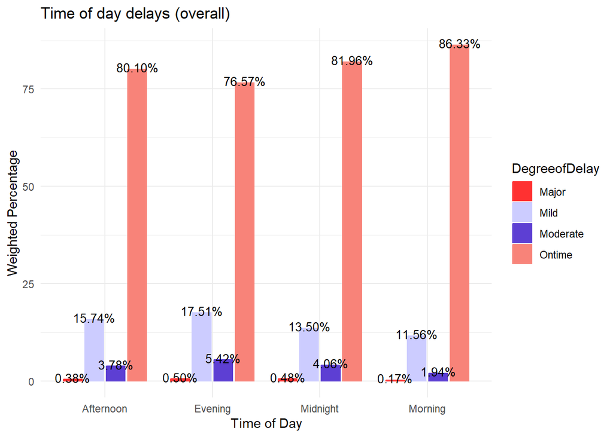

```r
tod_overall_g <- ggplot(time_of_day_df, aes(x = DepTimeOfDay, y = WeightedPercentage)) +
  geom_col(aes(color = DegreeofDelay, fill = DegreeofDelay), position = position_dodge(0.8), width = 0.7) + #dodge to unstack bar
  scale_color_manual(values = c("#FF3131", "#CCCCFF","#5D3FD3","#F88379"))+ #maps the colours for each degree of delay
  scale_fill_manual(values = c("#FF3131", "#CCCCFF","#5D3FD3","#F88379"))+
  geom_text(aes(label =sprintf("%.2f%%", WeightedPercentage), group = DegreeofDelay), position = position_dodge(0.8),vjust = 0.3, size = 3.5)+ #("%.2f%", weightedpercentage) indicates the text anotations and the format being a string with 2 decimal places and % attached to the string
  labs(title = "Time of day delays (overall)",
       x = "Time of Day",
       y = "Weighted Percentage") +
  theme_minimal()

tod_overall_g
```

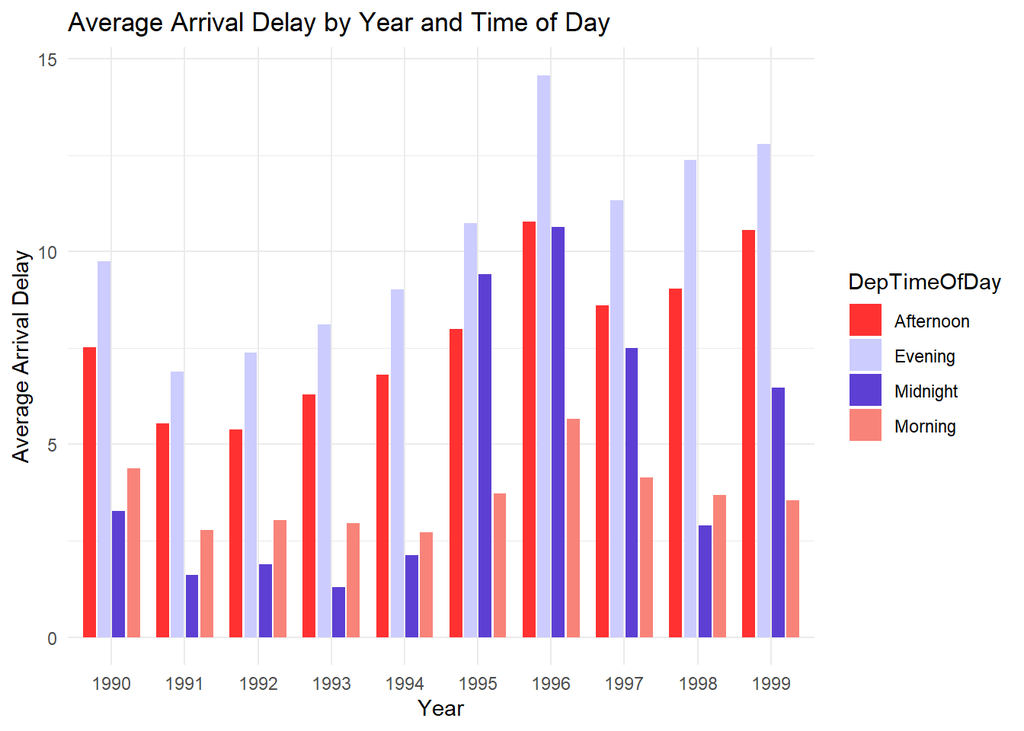

```r
tod_year_df$Year <- factor(tod_year_df$Year)

tod_year_g <- ggplot(tod_year_df, aes(x = Year, y = AverageArrDelay)) +
  geom_col(aes(fill = DepTimeOfDay), position = position_dodge(0.8), width = 0.7) +
  scale_fill_manual(values = c("#FF3131", "#CCCCFF","#5D3FD3","#F88379")) +
  labs(title = "Average Arrival Delay by Year and Time of Day",
       x = "Year",
       y = "Average Arrival Delay") +
  theme_minimal()
tod_year_g
```

**Answer to question: When is the best time of day to fly to minimize delay?**

```r
highest_ontime_percentage_time_of_day_df <- time_of_day_df %>%
 filter(DegreeofDelay == "Ontime") %>% arrange(desc(WeightedPercentage))

print(paste("The best time of day to travel to minimise delays is in the", tolower(head(highest_ontime_percentage_time_of_day_df$DepTimeOfDay,1)),"with a weighted percentage delay of", 100 - head(highest_ontime_percentage_time_of_day_df$WeightedPercentage,1),"%"))
```

```
## [1] "The best time of day to travel to minimise delays is in the morning with a weighted percentage delay of 13.67 %"
```

```r
# Creating data frame for minimum average delay per year
lowest_delay_by_year_df <- tod_year_df %>%
  group_by(Year) %>%
  filter(AverageArrDelay == min(AverageArrDelay)) %>%
  dplyr :: select(Year, DepTimeOfDay, AverageArrDelay)

# for loop to print best time to travel each year
for (year in unique(lowest_delay_by_year_df$Year)) {
  year_data <- lowest_delay_by_year_df %>% filter(Year == year)
  best_time_of_day <- year_data$DepTimeOfDay[which.min(year_data$AverageArrDelay)]
  cat("For", year, "the best time of day to travel is", best_time_of_day, "\n")
}
```

```
## For 1990 the best time of day to travel is Midnight
## For 1991 the best time of day to travel is Midnight
## For 1992 the best time of day to travel is Midnight
## For 1993 the best time of day to travel is Midnight
## For 1994 the best time of day to travel is Midnight
## For 1995 the best time of day to travel is Morning
## For 1996 the best time of day to travel is Morning
## For 1997 the best time of day to travel is Morning
## For 1998 the best time of day to travel is Midnight
## For 1999 the best time of day to travel is Morning
```

The worst time to fly is in the evening, as it has the highest weighted percentage for major delays and lowest weighted percentage for flights that are on time. Across the decade, the average delays in the evening is also the highest while mornings and midnights tend to have lower average delays.

## Part 2(a.ii): When is the best day of the week to fly to minimise delay?

The definition of delays for this part is the same as the definition for delay in Part 2(a.i), the approach to quantifying the delays for each day of the week for each year will be taking the mean arrival delay, similar to question 2(a.i).

**Creating Data Frames**

```r
day_of_week_df <- manifest_df %>%
  filter(!is.na(DayOfWeekString), !is.na(DegreeofDelay) & DegreeofDelay != "") %>%
  count(DayOfWeekString, DegreeofDelay) %>%
  group_by(DayOfWeekString) %>%
  mutate(WeightedPercentage = round((n / sum(n)) * 100, 2))
day_order <- c("Monday", "Tuesday", "Wednesday", "Thursday", "Friday", "Saturday", "Sunday")
day_of_week_df$DayOfWeek <- factor(day_of_week_df$DayOfWeekString, levels = day_order) #ensures that the graph plots in day order

head(day_of_week_df,5)
```

```
## # A tibble: 5 × 5
## # Groups:   DayOfWeekString [2]
##   DayOfWeekString DegreeofDelay       n WeightedPercentage DayOfWeek
##   <chr>           <chr>           <int>              <dbl> <fct>
## 1 Friday          Major           33491               0.45 Friday
## 2 Friday          Mild          1277355              17.0  Friday
## 3 Friday          Moderate       326392               4.34 Friday
## 4 Friday          Ontime        5886084              78.2  Friday
## 5 Monday          Major           21779               0.29 Monday
```

```r
#data frame for each year
dow_year_df <- manifest_df %>%
  group_by(Year,DayOfWeekString) %>%
  summarise(AverageArrDelay = mean(ArrDelay, na.rm = TRUE), .groups = "drop")
dow_year_df$DayOfWeekString <- factor(dow_year_df$DayOfWeekString, levels = day_order) #day_order defined in chunk above

head(dow_year_df,5)
```

```
## # A tibble: 5 × 3
##    Year DayOfWeekString AverageArrDelay
##   <int> <fct>                     <dbl>
## 1  1990 Friday                    11.2
## 2  1990 Monday                     4.82
## 3  1990 Saturday                   5.24
## 4  1990 Sunday                     4.96
## 5  1990 Thursday                   9.96
```

**Graph for visualization**

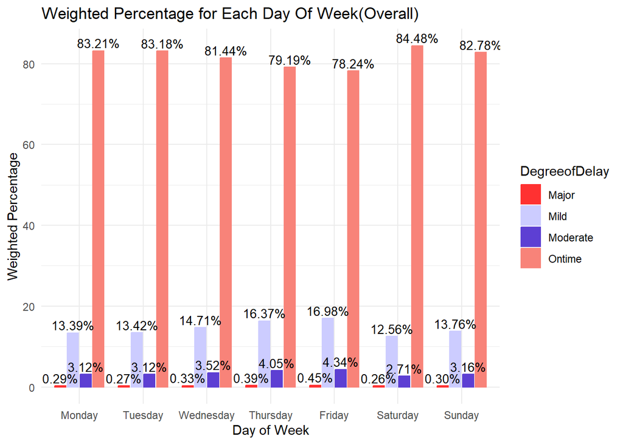

```r
# graph for overall best day
# Explanation of arguments are similar to overall plot in 2ai)
dow_overall_g <- ggplot(day_of_week_df, aes(x = DayOfWeek, y = WeightedPercentage)) +
  geom_col(aes(color = DegreeofDelay, fill = DegreeofDelay), position = position_dodge(0.8), width = 0.7) +
  scale_color_manual(values = c("#FF3131", "#CCCCFF","#5D3FD3","#F88379")) +
  scale_fill_manual(values = c("#FF3131", "#CCCCFF","#5D3FD3","#F88379")) +
  geom_text(aes(label =sprintf("%.2f%%", WeightedPercentage), group = DegreeofDelay),
            position = position_dodge(0.8), vjust = -0.3, size = 3.5) +
  labs(title = "Weighted Percentage for Each Day Of Week(Overall)",
       x = "Day of Week",
       y = "Weighted Percentage") +
  theme_minimal()
dow_overall_g
```

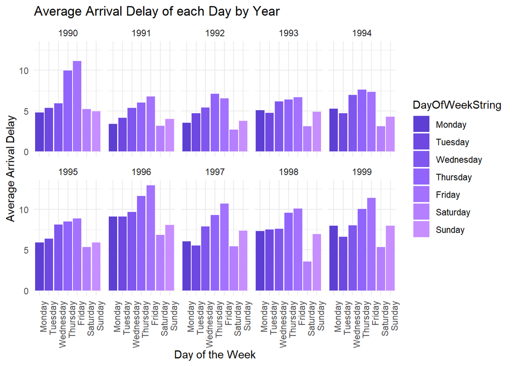

```r
#graph for yearly best day
dow_year_g <- ggplot(dow_year_df, aes(x = DayOfWeekString, y = AverageArrDelay)) +
   geom_bar(stat = "identity", position = "dodge", aes(fill = DayOfWeekString)) + #since the mean is calculated when creating the data frame, stat= "identity" is used to plot directly from the data frame
   facet_wrap(~ Year, nrow = 2) + #facet wrap allows all the graphs to be clumped together in 1 output sharing the same legend this gives a 2x5 grid to plot 10 graphs
   labs(title = "Average Arrival Delay of each Day by Year",
       x = "Day of the Week", y = "Average Arrival Delay") +
   theme_minimal() +
   theme(axis.text.x = element_text(angle = 90, hjust = 1)) + #label angled at 90 degrees to ensure graph redabilit
   scale_fill_manual(values = c("#5D3FD3", "#6E48E1", "#7F56EE", "#9164FB", "#A372FF", "#B580FF", "#C78EFF"))

dow_year_g
```

**Answer to question: When is the best day of the week to fly to minimize delay?**

```r
highest_ontime_percentage_day_of_week_df <- day_of_week_df %>%
 filter(DegreeofDelay == "Ontime") %>% arrange(desc(WeightedPercentage))

print(paste("The best day of the week to travel to minimise delays is on", tolower(head(highest_ontime_percentage_day_of_week_df$DayOfWeekString,1)),"with a weighted percentage delay of", 100 - head(highest_ontime_percentage_day_of_week_df$WeightedPercentage,1),"%"))
```

```
## [1] "The best day of the week to travel to minimise delays is on saturday with a weighted percentage delay of 15.52 %"
```

```r
#Creating data frame for minimum average delay per year
lowest_delay_dow_year_df <- dow_year_df %>%
  group_by(Year) %>%
  filter(AverageArrDelay == min(AverageArrDelay)) %>%
  dplyr :: select(Year, DayOfWeekString, AverageArrDelay)
lowest_delay_dow_year_df$DayOfWeekString <-  as.character(lowest_delay_dow_year_df$DayOfWeekString) #need to change back to chr so that the output is day instead of the number associated to the day

#for loop to print best time to travel each year
for (year in unique(lowest_delay_dow_year_df$Year)) {
  year_df <- lowest_delay_dow_year_df %>% filter(Year == year)
  cat("For", year, "the best day to travel is", year_df$DayOfWeekString, "\n")
}
```

```
## For 1990 the best day to travel is Monday
## For 1991 the best day to travel is Saturday
## For 1992 the best day to travel is Saturday
## For 1993 the best day to travel is Saturday
## For 1994 the best day to travel is Saturday
## For 1995 the best day to travel is Saturday
## For 1996 the best day to travel is Saturday
## For 1997 the best day to travel is Saturday
## For 1998 the best day to travel is Saturday
## For 1999 the best day to travel is Saturday
```

The worst time to fly is on Thursdays and Fridays, as it has the two days have the highest weighted percentage for major delays and lowest weighted percentage for flights that are on time. Across the decade, the average delays on the 2 days are also the highest while saturdays tend to have lower average delays.

## Part 2 (b). Evaluate whether older planes suffer more delays on a year-to-year basis

In this analysis, the delay is not specified, thus both arrival and departure delays are analysed. To make the analysis simple, we will look at the average delays. A plane would be considered old when it is more than 20 years old. We will be performing a correlation analysis on age of plane and delays.

It is important to note that tail number for years 1990 to 1994 is not available and thus cannot be used for this analysis as there is no other way to merge and identify the plane.

Classification of correlations, in absolute values:  
Perfect Correlation (1)  
Strong Correlation (0.7 to 0.99)  
Moderate Correlation (0.5 to 0.69)  
Weak Correlation (0.3 to 0.49)  
No Correlation (0 to 0.29)

This analysis will look at the overall delays and also on a year to year basis.

**Creating the data frame for delays**

```r
#Cleaning Planes data
planes_df$year <- as.integer(planes_df$year) #ensures that all the different forms of null is converted into "null"
str(planes_df)
```

```
## 'data.frame':    5029 obs. of  9 variables:
##  $ tailnum      : chr  "N050AA" "N051AA" "N052AA" "N054AA" ...
##  $ type         : chr  "" "" "" "" ...
##  $ manufacturer : chr  "" "" "" "" ...
##  $ issue_date   : chr  "" "" "" "" ...
##  $ model        : chr  "" "" "" "" ...
##  $ status       : chr  "" "" "" "" ...
##  $ aircraft_type: chr  "" "" "" "" ...
##  $ engine_type  : chr  "" "" "" "" ...
##  $ year         : int  NA NA NA NA NA NA NA NA NA NA ...
```

```r
# Data frame for age of planes and delays for every year
# Joins both data frames by the tailnumber and finds average delay grouped by age
delay_planes_df <- manifest_df %>%
  rename_all(tolower) %>%
  inner_join(planes_df, by = "tailnum", suffix = c(".manifest_df", ".planes_df")) %>% # this is where 1990 - 1994 data is left out as tailnum is all NA
  filter(year.planes_df != 0) %>% #since some null years data = 0 this takes care of those rows
  rename(YearOfFlight = year.manifest_df, YearOfManufacture = year.planes_df) %>%
  mutate(AgeOfPlane =YearOfFlight - YearOfManufacture) %>%
  group_by(YearOfFlight,AgeOfPlane) %>%
  filter(!is.na(AgeOfPlane), AgeOfPlane >= 0) %>%
  summarise(AverageArrDelay = mean(arrdelay, na.rm = TRUE),
            CountArrDelay = sum(!is.na(arrdelay)),
            AverageDepDelay = mean(depdelay, na.rm = TRUE),
            CountDepDelay = sum(!is.na(depdelay)), .groups = "drop")

head(delay_planes_df,5)
```

```
## # A tibble: 5 × 6
##   YearOfFlight AgeOfPlane AverageArrDelay CountArrDelay AverageDepDelay
##          <int>      <int>           <dbl>         <int>           <dbl>
## 1         1995          0            7.04         31741            8.49
## 2         1995          1            5.75         77639            6.99
## 3         1995          2            6.80         70505            8.28
## 4         1995          3            6.29        176856            7.93
## 5         1995          4            7.18        184458            8.51
## # ℹ 1 more variable: CountDepDelay <int>
```

```r
#Data frame for each year split into a list of 5 data frames
delay_planes_yearly_df <- split(delay_planes_df,delay_planes_df$YearOfFlight)

head(delay_planes_yearly_df, 5)
```

```
## $`1995`
## # A tibble: 34 × 6
##    YearOfFlight AgeOfPlane AverageArrDelay CountArrDelay AverageDepDelay
##           <int>      <int>           <dbl>         <int>           <dbl>
##  1         1995          0            7.04         31741            8.49
##  2         1995          1            5.75         77639            6.99
##  3         1995          2            6.80         70505            8.28
##  4         1995          3            6.29        176856            7.93
##  5         1995          4            7.18        184458            8.51
##  6         1995          5            7.48        190832            8.84
##  7         1995          6            8.00        164335            9.18
##  8         1995          7            7.25        179286            8.40
##  9         1995          8            7.17        173864            8.07
## 10         1995          9            7.25         95750            7.99
## # ℹ 24 more rows
## # ℹ 1 more variable: CountDepDelay <int>
##
## $`1996`
## # A tibble: 35 × 6
##    YearOfFlight AgeOfPlane AverageArrDelay CountArrDelay AverageDepDelay
##           <int>      <int>           <dbl>         <int>           <dbl>
##  1         1996          0           11.4          19396           11.7
##  2         1996          1            9.65         55063            9.69
##  3         1996          2            9.43         78602            9.44
##  4         1996          3           10.1          69999           10.4
##  5         1996          4            9.91        181721           10.6
##  6         1996          5           10.1         185860           10.3
##  7         1996          6           10.9         185130           10.9
##  8         1996          7           11.0         163510           11.1
##  9         1996          8            9.82        174919            9.79
## 10         1996          9           10.1         164390            9.71
## # ℹ 25 more rows
## # ℹ 1 more variable: CountDepDelay <int>
##
## $`1997`
## # A tibble: 36 × 6
##    YearOfFlight AgeOfPlane AverageArrDelay CountArrDelay AverageDepDelay
##           <int>      <int>           <dbl>         <int>           <dbl>
##  1         1997          0            6.47         26112            7.86
##  2         1997          1            7.89         44713            8.81
```

[output cut: 29 more lines]

```
## # A tibble: 38 × 6
##    YearOfFlight AgeOfPlane AverageArrDelay CountArrDelay AverageDepDelay
##           <int>      <int>           <dbl>         <int>           <dbl>
##  1         1999          0            6.46         69719            8.04
##  2         1999          1            7.17        171957            8.36
##  3         1999          2            7.49         66091            8.36
##  4         1999          3            6.95         44738            8.10
##  5         1999          4            6.86         53918            7.69
##  6         1999          5            8.55         70172            8.62
##  7         1999          6            7.36         71170            8.26
##  8         1999          7            7.52        182291            8.64
##  9         1999          8            7.49        187770            8.39
## 10         1999          9            9.10        193686            9.72
## # ℹ 28 more rows
## # ℹ 1 more variable: CountDepDelay <int>
```

**Answer to the question: Do older planes suffer more delays?**

**Overall correlation**  
We want to first have an initial visual representation of the relationship between the age of planes, average departure delay and average arrival delay

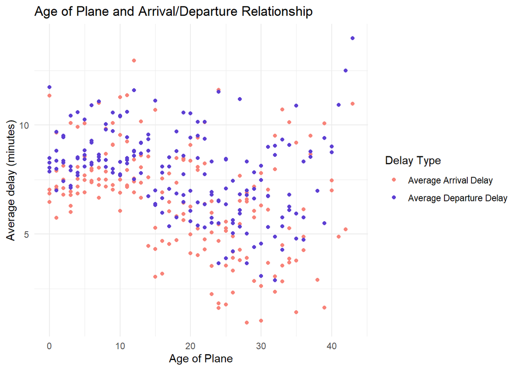

```r
# Graph for visualization
 ggplot() + # Overlay both departure and arrival delays for comparison
  geom_point(data = delay_planes_df, aes(x = AgeOfPlane, y = AverageArrDelay, color = "Average Arrival Delay")) +
  geom_point(data = delay_planes_df, aes(x = AgeOfPlane, y = AverageDepDelay, color = "Average Departure Delay")) +
  labs(title = "Age of Plane and Arrival/Departure Relationship", x = "Age of Plane", y = "Average delay (minutes)") +
  scale_color_manual(name = "Delay Type", values = c("Average Arrival Delay" = "#F88379", "Average Departure Delay" = "#5D3FD3")) + #creating the legend
  theme_minimal()
```

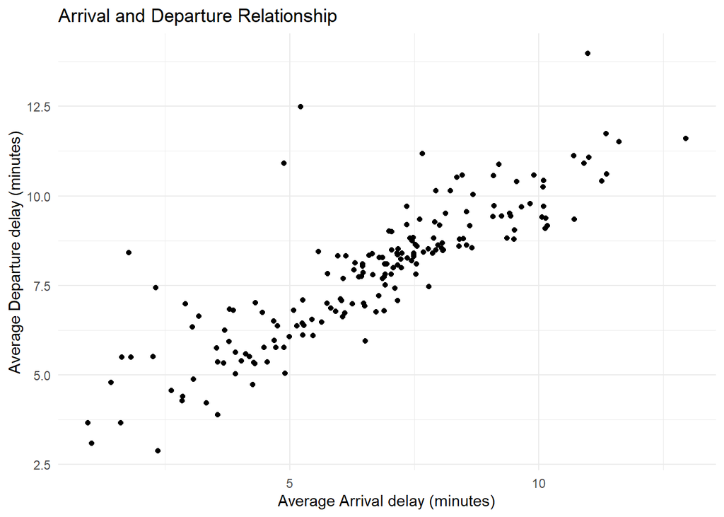

```r
ggplot(delay_planes_df, aes(x = AverageArrDelay , y = AverageDepDelay)) +
  geom_point() +
  labs(title = "Arrival and Departure Relationship", x = "Average Arrival delay (minutes)", y = "Average Departure delay (minutes)") +
  theme_minimal()
```

It can be implied from the 2 plots that the age of plane seems to have a weak negative linear correlation on average arrival and delay (in minutes). While the average arrival and delay has a strong positive linear correlation. We now want to test the pearson correlation to have statistical values and create a correlation plot between the 3 variables.

```r
#correlation test between age of plane and arrival delay/departure delay (overall)
cor.test(delay_planes_df$AgeOfPlane,delay_planes_df$AverageArrDelay)
```

```
##
##  Pearson's product-moment correlation
##
## data:  delay_planes_df$AgeOfPlane and delay_planes_df$AverageArrDelay
## t = -5.9001, df = 178, p-value = 1.793e-08
## alternative hypothesis: true correlation is not equal to 0
## 95 percent confidence interval:
##  -0.5199526 -0.2744176
## sample estimates:
##        cor
## -0.4044476
```

```r
cor.test(delay_planes_df$AgeOfPlane,delay_planes_df$AverageDepDelay)
```

```
##
##  Pearson's product-moment correlation
##
## data:  delay_planes_df$AgeOfPlane and delay_planes_df$AverageDepDelay
## t = -4.4143, df = 178, p-value = 1.753e-05
## alternative hypothesis: true correlation is not equal to 0
## 95 percent confidence interval:
##  -0.4401596 -0.1759391
## sample estimates:
##       cor
## -0.314119
```

```r
cor.test(delay_planes_df$AverageArrDelay,delay_planes_df$AverageDepDelay)
```

```
##
##  Pearson's product-moment correlation
##
## data:  delay_planes_df$AverageArrDelay and delay_planes_df$AverageDepDelay
## t = 21.805, df = 178, p-value < 2.2e-16
## alternative hypothesis: true correlation is not equal to 0
## 95 percent confidence interval:
##  0.8074776 0.8884201
## sample estimates:
##       cor
## 0.8529981
```

**Correlation plot**

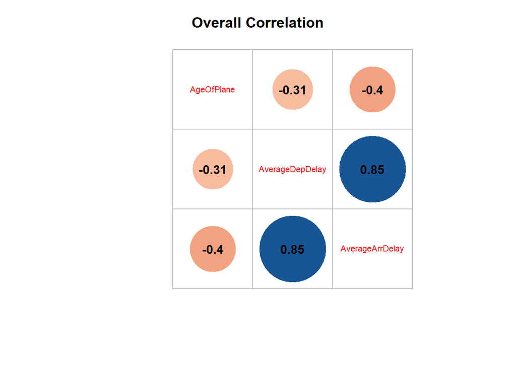

```r
#Setting up the correlation matrix
delay_planes_corr_df <- delay_planes_df %>%
  dplyr :: select(AgeOfPlane,AverageDepDelay,AverageArrDelay)
correlation_matrix <- cor(delay_planes_corr_df)

#Plotting the correlation plot
corrplot::corrplot(correlation_matrix, order = 'AOE', addCoef.col = 'black', tl.pos = 'd', cl.pos = 'n', col = COL2('RdBu'),tl.cex = 0.7, cl.cex = 0.7,mar = c(5, 5, 3, 5), main = "Overall Correlation") # 'AOE' gives the circles its different sizes and addcoeff.col gives each correlation coefficient the rest is aesthetic and scaling the graph to fit the output size
```

As per our visual inspection, the overall correlation of age of plane with average departure delay and average arrival delay are both weak negative linear correlations. The average arrival delays do have a slightly higher correlation with the age of a plane compared to the average departure delays.

**Individual year correlations**  
For the individual years, only the correlation plot will be plotted as it is the most effective and compact way to visualise all the correlation coefficients across every year.

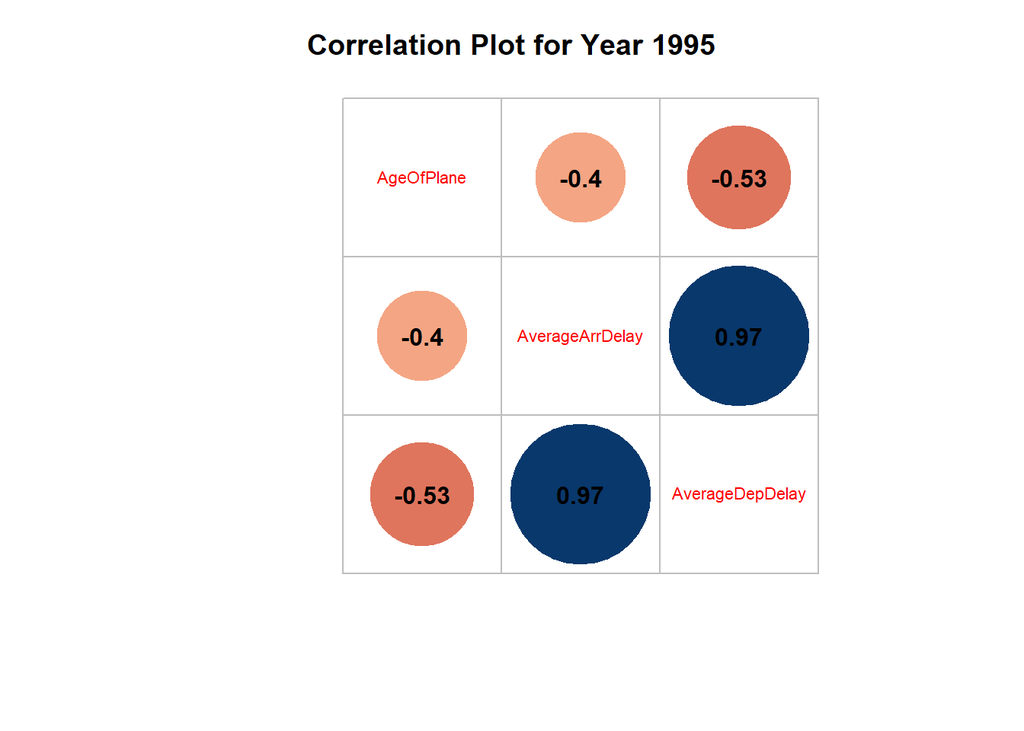

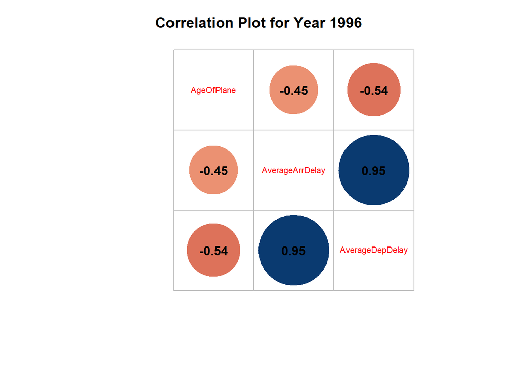

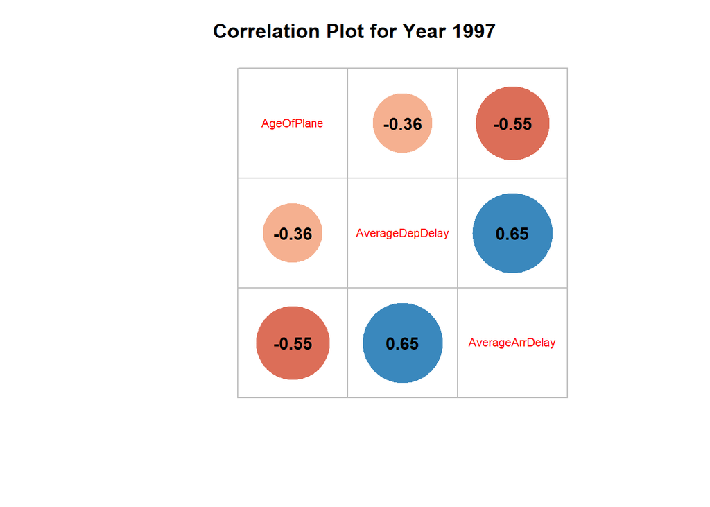

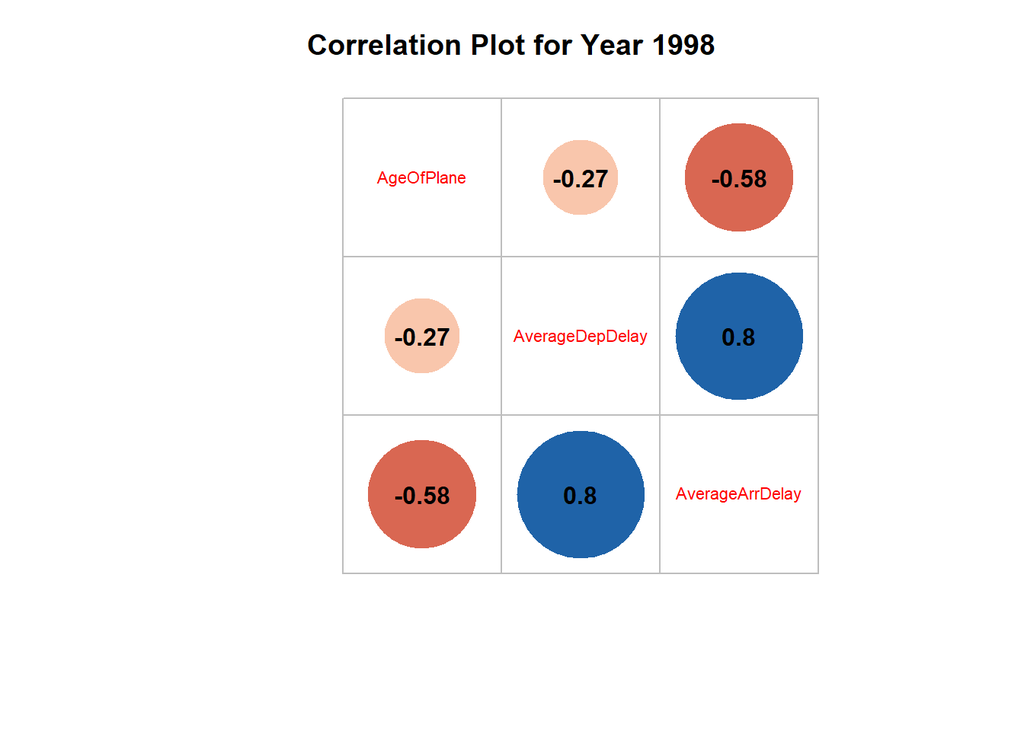

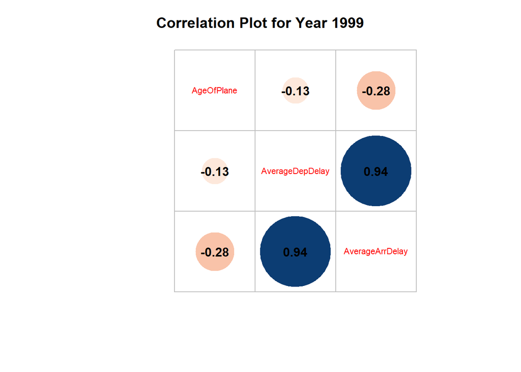

```r
# for loop to plot each year's data frame
for (i in seq_along(delay_planes_yearly_df)) {
    current_yearly_delay_df <- delay_planes_yearly_df[[i]]

    #selecting the correlation variables
    corr_var <- current_yearly_delay_df[, c("AgeOfPlane", "AverageDepDelay", "AverageArrDelay")]
    correlation_matrix <- cor(corr_var)

    # Plotting the correlation matrix
    corrplot(correlation_matrix, order = 'AOE', addCoef.col = 'black', tl.pos = 'd',cl.pos = 'n', col = COL2('RdBu'), tl.cex = 0.7, cl.cex = 0.7,mar = c(5, 5, 3, 5),main = paste("Correlation Plot for Year", unique(current_yearly_delay_df$YearOfFlight)))
}
```

Across the 5 years, we see that there is a negative correlation between the age of planes and the average delays for both departure and arrivals. For years 1995 and 1996, there is a moderate negative linear correlation with age of plane and average departure delay while there is a weak negative linear correlation with age of plane and average arrival delay. For years 1997 and 1998, there is a moderate negative linear correlation with age of plane and average arrival delay. For 1997 there is a weak negative linear correlation with age of plane and average departure delay while 1998 has no correlation between age of plane and average departure delay. In 1999, there is no correlation between age of planes and average delays for both departure and arrivals.

In general, the age of a plane has weak negative linear correlation with delays. However, it seems that older planes suffer from less delays than newer planes. However, older planes seem to be more inconsistent than younger planes. This may be due to the reliability of older planes using tired and tested parts while some new planes be using experimental parts, while this cannot be confirmed statistically it may be a factor as to why older planes have less delays than newer planes.

## Part 2 (c) Logistic regression

In this part, the visualisation of the probabilities will be plotted with a dot plot where the fitted values(predicted probabilities of each flight) will be plotted against each independent variable. The mean fitted values for each year will then be plotted across the years to see how the probability of diverted flights change across the years. Finally, a logistic regression will be done for each year to get the yearly coefficients for each independent variable while will be plotted in a line plot to visualize how the coefficients change across the years.

Since the glm function requires alot of memory to execute, a smaller sample 20% of the manifest dataframe will be drawn using a stratified split method to ensure there is representation for diverted flights. This sample manifest data frame will be used to test some assumptions and build our regression model and where its accuracy will be tested. The generated model from this sample data set will then be used for the 10 years of data to draw the relevant insights. PS. There is no need to perform this step if the system has sufficient memory.

The main assumption that will be tested is for perfect multicollinearity as long as the correlation is not equal to 1, the assumption is satisfied.

```r
#clearing the environment for maximum available memory
#Maximising avaiable memory
items_to_keep <- c("manifest_df","airports_df", "carriers_df", "planes_df")
all_objects <- ls()
objects_to_remove <- setdiff(all_objects, items_to_keep)
rm(list = objects_to_remove)
```

Looking at the data set again, since a logistic regression can only take on numerical variables, to include carriers the variables will need to be converted into dummy variables or ordinal variables. While coding a dummy variable is ideal, there are way to many carriers to consider this approach, as such we will treat it as an ordinal variable. Month and day will also be treated as an ordinal variable as dummy variables for these 2 variables will result in memory errors or a very long run time often resulting in a crash.

```r
#Setting up the data frame for regression
manifest_df$Diverted <- factor(manifest_df$Diverted) #changing diverted to a factor (binary dependent variable)

#Creating numerical index for and carriers
carriers_df$code_n <- row.names(carriers_df) #index
carriers_df$code_n <- as.integer(as.character(carriers_df$code_n)) #ensuring its a integer for logistic regresison

# Merging the dataframes and retreiving the code_n
regression_manifest_df <- manifest_df %>%
  inner_join(carriers_df, by =c("UniqueCarrier"= "Code"), suffix = c(".manifest_df", ".carriers_df")) %>%
  dplyr :: select(Year,Month,DayOfWeek,DepTime,CRSDepTime,CRSArrTime,Distance,CRSElapsedTime,code_n,Diverted)
regression_manifest_df<- na.omit(regression_manifest_df)

head(regression_manifest_df,5)
```

```
##   Year Month DayOfWeek DepTime CRSDepTime CRSArrTime Distance CRSElapsedTime
## 1 1990     1         3    1707       1630       1723      182             53
## 2 1990     1         4    1706       1630       1723      182             53
## 3 1990     1         5    1629       1630       1723      182             53
## 4 1990     1         6    1633       1630       1723      182             53
## 5 1990     1         1    1630       1630       1723      182             53
##   code_n Diverted
## 1   1309        0
## 2   1309        0
## 3   1309        0
## 4   1309        0
## 5   1309        0
```

```r
#Checking for diverted in whole data frame
diverted_count <- sum(regression_manifest_df$Diverted == 1)
total_rows <- nrow(regression_manifest_df)
percentage_diverted <- (diverted_count/total_rows)*100
percentage_diverted
```

```
## [1] 0.2389776
```

Since a 0.23% of the data contains diverted flights it is important that our sample data frame contains the same percentage of diverted flights as the full data frame. This is why we use a stratified split to create a sample. This approach will affect the accuracy, however given the limited memory, it is the best way to include as many features as possible and get a final model in a timely manner.

### Assumption test (No perfect multicollinearity)

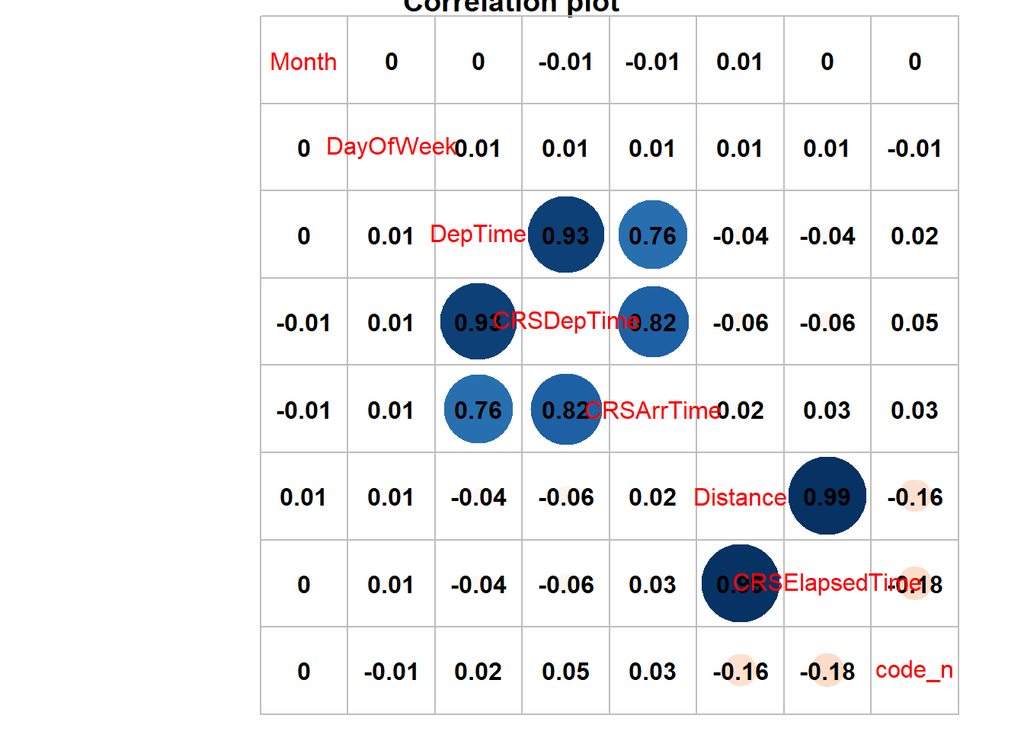

```r
selected_variables <- c("Month", "DayOfWeek", "DepTime", "CRSDepTime", "CRSArrTime", "Distance", "CRSElapsedTime","code_n")
#correlation matrix
correlation_matrix <- cor(regression_manifest_df[, selected_variables])

# Plotting the correlation matrix
corrplot(correlation_matrix, addCoef.col = 'black', tl.pos = 'd', cl.pos = 'n', col = COL2('RdBu'), main = "Correlation plot")
```

It can be seen that there are some variables with high pairwise correlations, mainly distance and CRSElapsedTime which have a correlation score of 0.99, thus distance is removed from the model as it is less significant compared to CRSElapsedTime in previous iterations of running the model. Since none of the other pairwise correlation = 1, the assumption of no perfect multicollinerity is satisfied. It is also noted that the pairs with high correlation is expected where a larger flight distance would result in more scheduled time, and the arrival and departure times being highly correlated is expected as well.

### Sampling

Since the number of diverted flights is very low we want to ensure representation for the diverted flights thus we will use a stratified split method to extract a sample for our logistic regression model.

```r
# Seed set for reproducability
set.seed(123)
# Generate random indices for the sample data frame
sample_ratio <- 0.2

# Creating stratified split rule
strat_split <- initial_split(regression_manifest_df, prop = sample_ratio, strata = "Diverted") #stratification split with diverted as the target variable

# extracting the 20% sample
sample_manifest_df <- training(strat_split)

# checking for diverted in sample_manifest_df
table(sample_manifest_df$Diverted)
```

```
##
##        0        1
## 10299029    24616
```

```r
#Maximising available memory
items_to_keep <- c("regression_manifest_df", "sample_manifest_df")
all_objects <- ls()
objects_to_remove <- setdiff(all_objects, items_to_keep)
rm(list = objects_to_remove)
```

### Building the Logistic regression model and training

```r
# Initial model built with every feature shortlisted in "regression_manifest_df"
logit_diverted_initial <- glm(Diverted ~ Month + DayOfWeek +DepTime + CRSDepTime + CRSArrTime + CRSElapsedTime + code_n, data = sample_manifest_df, family = "binomial")
summary(logit_diverted_initial)
```

```
##
## Call:
## glm(formula = Diverted ~ Month + DayOfWeek + DepTime + CRSDepTime +
##     CRSArrTime + CRSElapsedTime + code_n, family = "binomial",
##     data = sample_manifest_df)
##
## Coefficients:
##                  Estimate Std. Error  z value Pr(>|z|)
## (Intercept)    -6.764e+00  3.216e-02 -210.302   <2e-16 ***
## Month          -2.928e-02  1.861e-03  -15.731   <2e-16 ***
## DayOfWeek      -9.409e-04  3.202e-03   -0.294    0.769
## DepTime         4.039e-04  3.201e-05   12.618   <2e-16 ***
## CRSDepTime     -3.915e-04  3.668e-05  -10.671   <2e-16 ***
## CRSArrTime      1.836e-04  2.035e-05    9.019   <2e-16 ***
## CRSElapsedTime  4.727e-03  7.758e-05   60.932   <2e-16 ***
## code_n         -2.815e-06  1.328e-05   -0.212    0.832
## ---
## Signif. codes:  0 '***' 0.001 '**' 0.01 '*' 0.05 '.' 0.1 ' ' 1
##
## (Dispersion parameter for binomial family taken to be 1)
##
##     Null deviance: 346475  on 10323644  degrees of freedom
## Residual deviance: 342494  on 10323637  degrees of freedom
## AIC: 342510
##
## Number of Fisher Scoring iterations: 9
```

The output shows DayOfWeek and Code_n (Unique carrier) are not significant with p values larger than 0.05. Therefore we use stepAIC from the “MASS” package to improve the model by automating the stepwise regression. The function runs the logistic regression each time removing the least significant variable to come up with the most accurate model possible.

### Improving the model

**Overall model**

```r
logit_diverted_model <- stepAIC(logit_diverted_initial) #stepwise regression function
```

```
## Start:  AIC=342510.4
## Diverted ~ Month + DayOfWeek + DepTime + CRSDepTime + CRSArrTime +
##     CRSElapsedTime + code_n
##
##                  Df Deviance    AIC
## - code_n          1   342494 342508
## - DayOfWeek       1   342494 342508
## <none>                342494 342510
## - CRSArrTime      1   342583 342597
## - CRSDepTime      1   342604 342618
## - DepTime         1   342637 342651
## - Month           1   342742 342756
## - CRSElapsedTime  1   345625 345639
##
## Step:  AIC=342508.4
## Diverted ~ Month + DayOfWeek + DepTime + CRSDepTime + CRSArrTime +
##     CRSElapsedTime
##
##                  Df Deviance    AIC
## - DayOfWeek       1   342495 342507
## <none>                342494 342508
## - CRSArrTime      1   342583 342595
## - CRSDepTime      1   342606 342618
## - DepTime         1   342639 342651
## - Month           1   342742 342754
## - CRSElapsedTime  1   345699 345711
##
## Step:  AIC=342506.5
## Diverted ~ Month + DepTime + CRSDepTime + CRSArrTime + CRSElapsedTime
##
##                  Df Deviance    AIC
## <none>                342495 342507
## - CRSArrTime      1   342583 342593
## - CRSDepTime      1   342606 342616
## - DepTime         1   342639 342649
## - Month           1   342743 342753
## - CRSElapsedTime  1   345699 345709
```

```r
summary(logit_diverted_model)
```

```
##
## Call:
## glm(formula = Diverted ~ Month + DepTime + CRSDepTime + CRSArrTime +
##     CRSElapsedTime, family = "binomial", data = sample_manifest_df)
##
## Coefficients:
##                  Estimate Std. Error  z value Pr(>|z|)
## (Intercept)    -6.770e+00  2.702e-02 -250.557   <2e-16 ***
## Month          -2.928e-02  1.861e-03  -15.730   <2e-16 ***
## DepTime         4.046e-04  3.183e-05   12.710   <2e-16 ***
## CRSDepTime     -3.922e-04  3.650e-05  -10.747   <2e-16 ***
## CRSArrTime      1.836e-04  2.035e-05    9.019   <2e-16 ***
## CRSElapsedTime  4.729e-03  7.678e-05   61.594   <2e-16 ***
## ---
## Signif. codes:  0 '***' 0.001 '**' 0.01 '*' 0.05 '.' 0.1 ' ' 1
##
## (Dispersion parameter for binomial family taken to be 1)
##
##     Null deviance: 346475  on 10323644  degrees of freedom
## Residual deviance: 342495  on 10323639  degrees of freedom
## AIC: 342507
##
## Number of Fisher Scoring iterations: 9
```

```r
#The final improved model formula = Diverted ~ Month + DepTime + CRSDepTime + CRSArrTime + CRSElapsedTime, family = "binomial"
```

After the stepwise regression model process is done, we see that DayOfWeek and Code_n (Unique carrier) are removed and all features are now highly significant.

**Ranking regressor/ features based on coefficient significance.**  
Looking at the output of “logit_diverted_model”, a larger absolute Z value implies a more significant regressor/ feature. From the most significant feature to the least, we have: CRSElapsedTime (61.594), Month (-15.730), DepTime (12.710), CRSDepTime (-10.747), CRSArrTime(9.019). From this it can be implied that a smaller scheduled elapsed time would result in a lower probability of diversions, which could also imply that shorter flights tend to divert less.

```r
#Maximising available memory
items_to_keep <- c("regression_manifest_df", "sample_manifest_df","logit_diverted_model")
all_objects <- ls()
objects_to_remove <- setdiff(all_objects, items_to_keep)
rm(list = objects_to_remove)
```

### Implementing the model on the full dataset

**Predicting Diverted flights using model**

```r
# Gives the predicted probabilities/ fitted values of the logistic regression for each flight
logit_diverted_predict <- predict(logit_diverted_model,regression_manifest_df,type = "response")
```

### Misclassification Error & Accuracy- Testing Data

```r
# Includes the fitted values into "regression_manifest_df" so that we can test accuracy and plot graphs
regression_manifest_df$Probability <- logit_diverted_predict
# Decides if the prediction is diverted or not
regression_manifest_df$Predict.diverted <- ifelse(logit_diverted_predict >= 0.5,1,0)
# Confusion matrix and accuracy to validate model
confusion_matrix <- table(Predicted = regression_manifest_df$Predict.diverted, Actual = regression_manifest_df$Diverted)
accuracy <- mean(regression_manifest_df$Predict.diverted == regression_manifest_df$Diverted)
print(paste("Model Accuracy:", accuracy))
```

```
## [1] "Model Accuracy: 0.997610224047211"
```

```r
print(confusion_matrix)
```

```
##          Actual
## Predicted        0        1
##         0 51494867   123351
##         1        5        5
```

The model accuracy of 99.7% is considered very good but there is the worry of over fitting the model. It can be seen that the model is able to predict true non-diverted flights well but not very well for true diverted flights.

### Plotting for Overall probability against all 5 retained regressors in logit_diverted_model

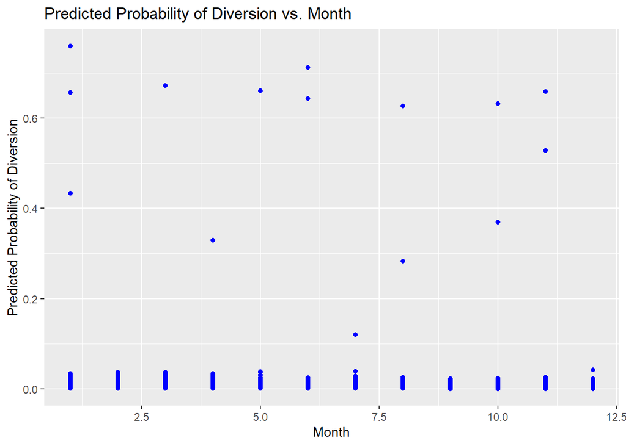

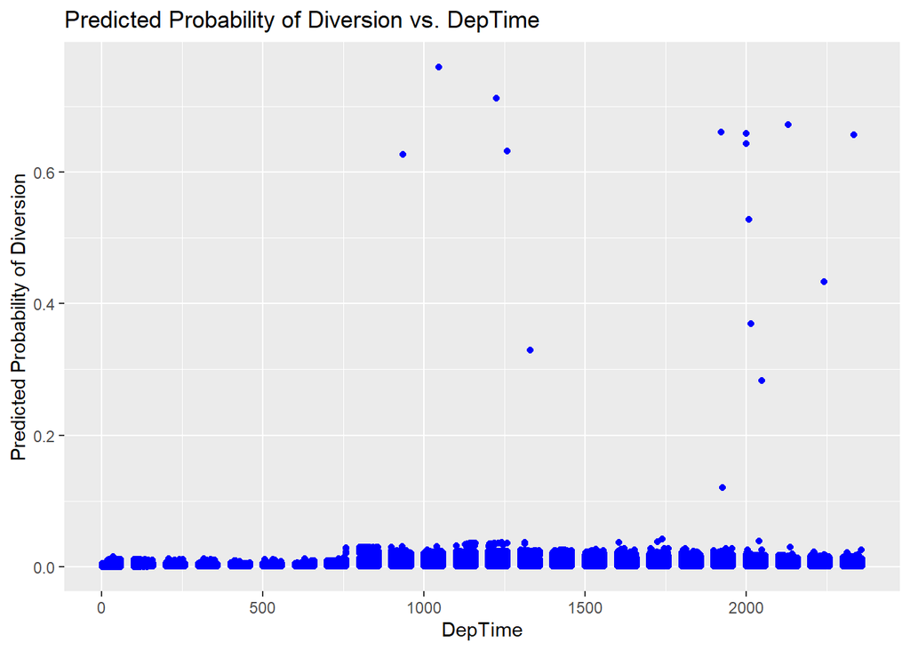

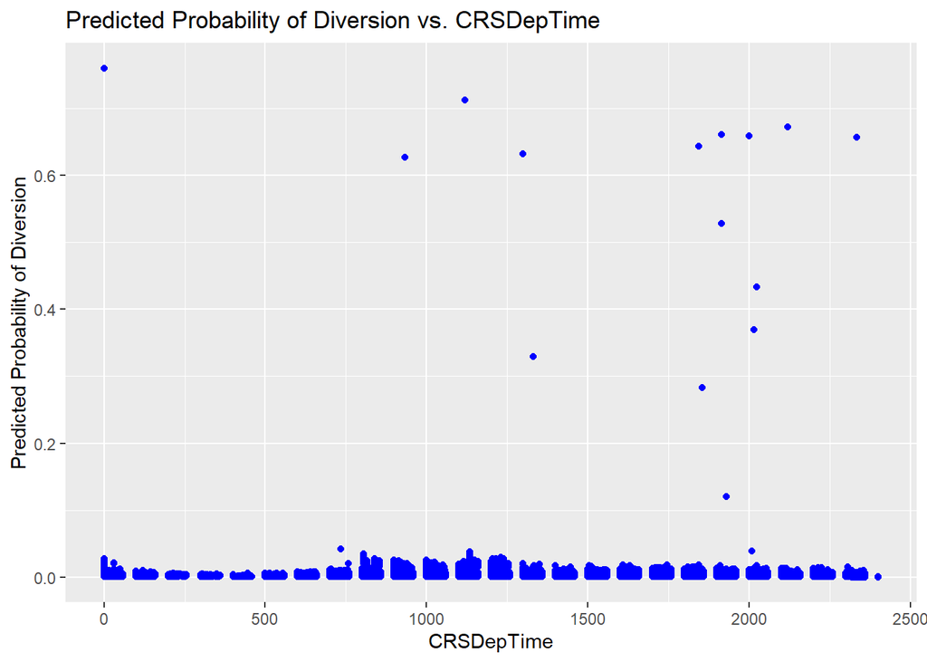

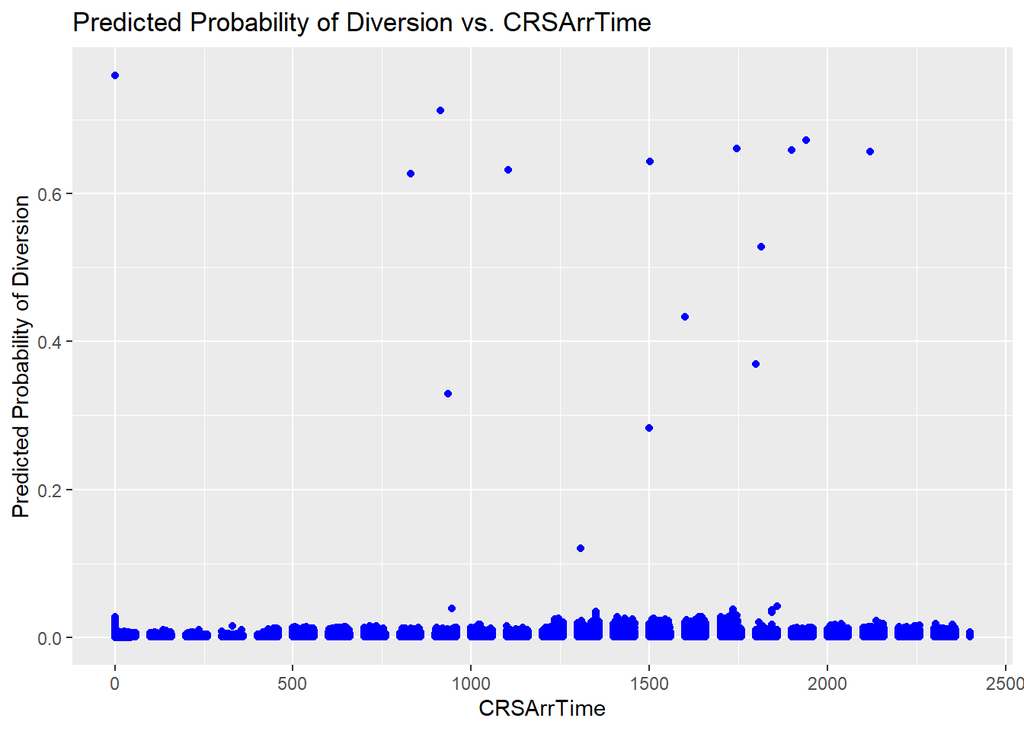

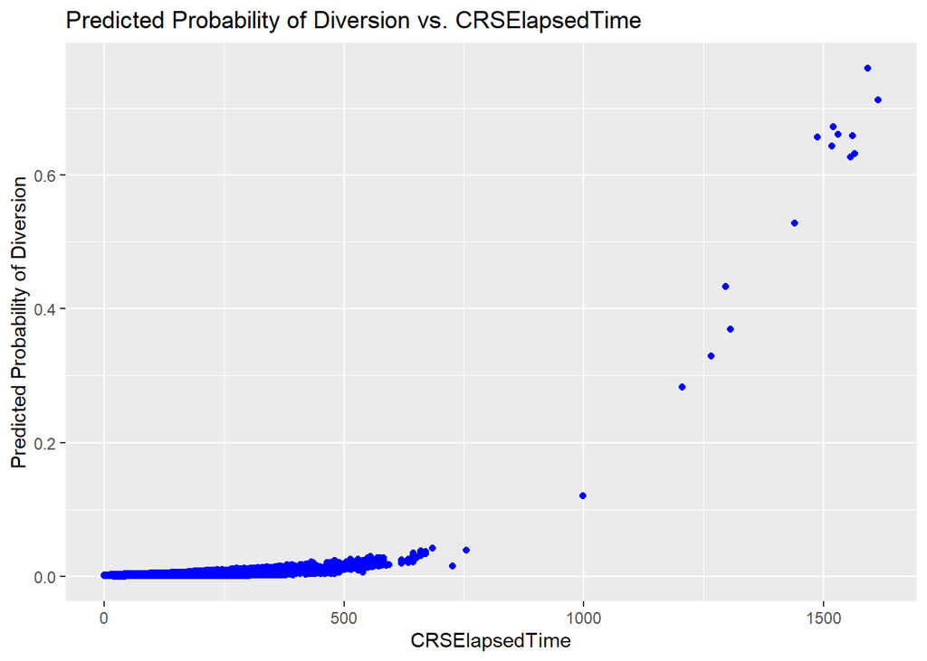

```r
independent_variables <- c("Month", "DepTime", "CRSDepTime", "CRSArrTime", "CRSElapsedTime") #manually defining the variables for plotting

# Create scatter plots for each independent variable
plots <- map(independent_variables, ~ { #iterates through every independent variable
  variable <- .x #in each iteration, .x carries the given variable
  ggplot(regression_manifest_df, aes(x = !!rlang::sym(variable), y = Probability)) + #using the data frame, x = !!rlang::sym(variable) allows the x axis to be dynamically assigned based on the iteration of .x, the independent variable
    geom_point(color = "blue") +
    labs(title = paste0("Predicted Probability of Diversion vs. ", variable),
         x = variable, y = "Predicted Probability of Diversion")
})

print(plots)
```

**Departure Time**  
As the departure times increase, the predicted probability of diversion also increases. This means that the model predicts that diverted flights tend to happen for frequently later into the day.

**Scheduled Arrival Time**  
As the scheduled arrival times increase, the predicted probability of diversion also increases. This means that the model predicts that diverted flights tend to happen for frequently when the flight is scheduled to land later into the day. The model predicts that most diverted flights are scheduled to land from 0700 to 2100. It is noted that there is one outlier where the flight is predicted to be diverted and it is scheduled to land around midnight.  
The scheduled arrival and departure predictions seem to have a very similar prediction, indicating that scheduled arrival times and departeure times are highly correlated.

**Scheduled Elapsed Time**  
The scheduled elapsed time shows an upward trend in diversion probabilty, where the longer the scheduled flight, the higher the probabilty of diversion. With all the predicted diverted flights having a scheduled elapsed time of 1400 minutes and above. This implies that the model is likely to predict that a flight is diverted if the longer the scheduled elapsed time.

```r
# Setting up the data frame to plot
yearly_mean_probabilities <- regression_manifest_df %>%
  group_by(Year) %>% summarise(Mean_Probability = mean(Probability, na.rm = TRUE), .groups = "drop")

head(yearly_mean_probabilities,5)
```

```
## # A tibble: 5 × 2
##    Year Mean_Probability
##   <int>            <dbl>
## 1  1990          0.00228
## 2  1991          0.00231
## 3  1992          0.00232
## 4  1993          0.00233
## 5  1994          0.00233
```

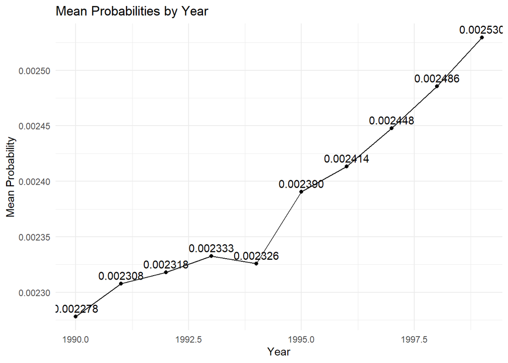

```r
mean_probabilities_g <- ggplot(yearly_mean_probabilities, aes(x = Year , y = Mean_Probability)) +
  geom_line() +
  geom_point() +
  labs(title = "Mean Probabilities by Year", x = "Year", y = "Mean Probability") +
  geom_text(aes(label = sprintf("%.6f", Mean_Probability)), vjust = -0.5, hjust = 0.5) +
  theme_minimal()

mean_probabilities_g
```

### Running the logit model for every year and storing the coefficents of regressors

```r
#splitting the data frame by year
yearly_manifest_df <- regression_manifest_df %>%
  group_split(Year)
```

```r
# Create empty data frame to store coefficients for logistic regression done for each year (10 sets total to be obtained)
coefficients_df <- data.frame(Year = integer(),
                              Month = numeric(),
                              DepTime = numeric(),
                              CRSDepTime= numeric(),
                              CRSArrTime = numeric(),
                              CRSElapsedTime = numeric())

# Loop through each yearly data frame
for (yearly_df in yearly_manifest_df) {
  # using the model from stepAIC
  model <- glm(Diverted ~ Month +DepTime + CRSDepTime + CRSArrTime + CRSElapsedTime, data = yearly_df, family = "binomial")

  # Extract coefficients
  coefficients <- coef(summary(model))[, "Estimate"]
  coefficients["Year"] <- unique(yearly_df$Year)
  coefficients_df <- rbind(coefficients_df, coefficients)
}

# intercept included as the model's output contains intercepts, but will not  be plotted
colnames(coefficients_df) <- c("Intercept","Month", "DepTime", "CRSDepTime", "CRSArrTime", "CRSElapsedTime","Year")

print(coefficients_df)
```

```
##    Intercept        Month       DepTime    CRSDepTime    CRSArrTime
## 1  -6.361163 -0.007375881  2.290291e-03 -2.190335e-03 -4.583802e-05
## 2  -6.417199 -0.040217358  1.999530e-03 -1.926203e-03 -4.162693e-05
## 3  -6.750481 -0.002766067  2.325361e-03 -2.219005e-03 -7.704452e-05
## 4  -6.481405 -0.054495570  2.203869e-03 -2.211376e-03 -1.710623e-05
## 5  -6.441224 -0.055758897  3.525035e-03 -3.517212e-03  1.716435e-05
## 6  -6.992058 -0.017063100  5.290083e-05  1.036398e-04  2.723110e-05
## 7  -6.775512 -0.015859628  1.268065e-04 -8.239657e-05  1.571502e-04
## 8  -7.070498 -0.022624840  4.043742e-05 -5.300225e-05  3.147488e-04
## 9  -7.254354 -0.013477692  1.641212e-04 -9.606200e-05  2.645842e-04
## 10 -6.707812 -0.062210149 -2.217822e-04  1.467765e-04  3.891152e-04
##    CRSElapsedTime Year
## 1     0.004277208 1990
## 2     0.004914897 1991
## 3     0.004929649 1992
## 4     0.005001264 1993
## 5     0.005167879 1994
## 6     0.004706238 1995
## 7     0.004860336 1996
## 8     0.004771249 1997
## 9     0.005915162 1998
## 10    0.004306795 1999
```

#Plotting the regressor coefficient across the 10 years

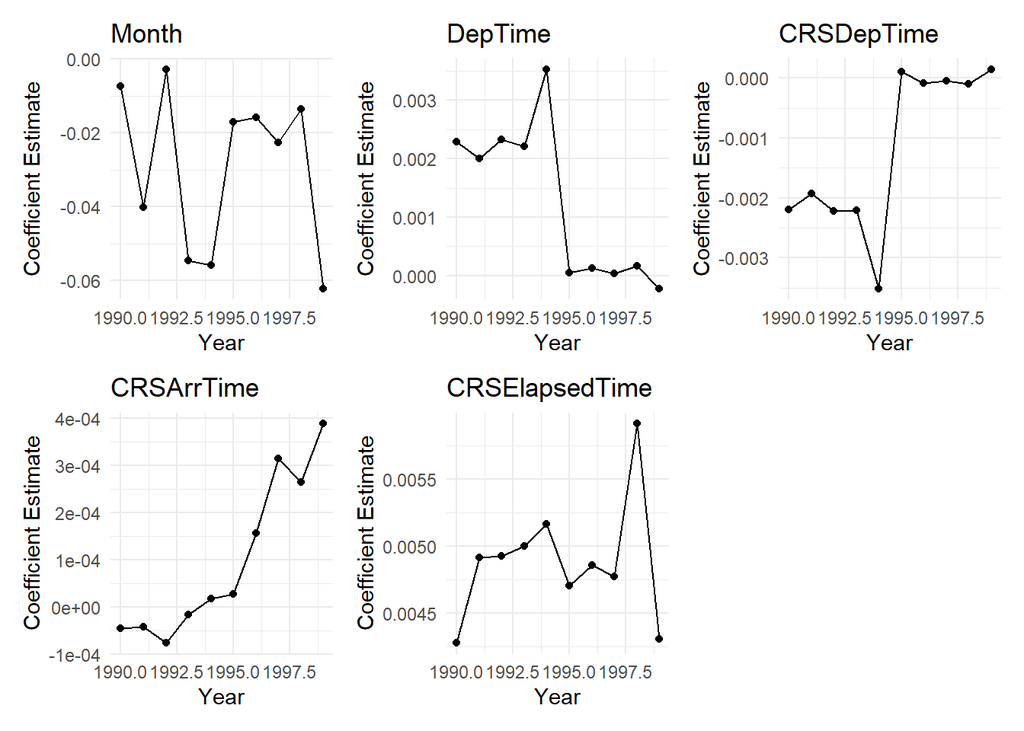

```r
# Function for plotting coefficients by the independent variable for a given iteration
plot_coefficients <- function(data, independent_variable) {
  ggplot(data, aes(x = Year, y = !!sym(independent_variable))) + # similar to the 5 plots above (diversion probability) except the iteration of the independent variable is now on the y axis
    geom_point() +
    geom_line() +
    labs(title = independent_variable, x = "Year", y = "Coefficient Estimate") +
    theme_minimal()
}

independent_variables <- c("Month", "DepTime", "CRSDepTime", "CRSArrTime", "CRSElapsedTime") #same as above plot

#plotting the graphs
plots_coef <- map(independent_variables, ~ plot_coefficients(coefficients_df, .x))
plots_coef <- reduce(plots_coef, `+`) #combines the plots into one output

plots_coef
```

**Month (ordinal)**  
Since the overall coefficients are negative, this means deeper into the year, the probability of diversion reduces. It is also noted that years 1993, 1994 and 1999, saw the coefficient estimate fall the lowest at to a value of -0.05 to -0.06. This implies that for these years the month has a larger influence on diversion probability.

**Scheduled Arrival Time (continuous)**  
Mostly positive coefficients estimates imply a positive relationship between scheduled arrival times and diversion probability. Seeing that the coefficient estimates grow larger over the years, this means that this feature gains influence over diversion probability throughout the decade.

**Scheduled Elapsed Time (continuous)**  
All positive coefficients estimates imply a positive relationship between scheduled elapsed times and diversion probability. 1998 had the largest coefficient estimate value implying that CRSElapsedTime had more influence over diversion probability compared to the other years with 1990 and 1999 showing the smallest amount of influence.

**Overall thoughts on the model**  
While the model is not very good in predicting diverted flights, it is good at predicting non diverted flights. The model may be improved by including dummy variables for unique carriers, origin airport and destination airport. However this approach would require a lot of memory from a computer as the unique variables would be up to almost 8000 as there are more than 3000 unique airports and more than 1000 unique carriers. Another way to improve the accuracy of the model is to have more diverted flights to train the model as a diversion rate of 0.23% might be too low to train the model adequately.